# RRBS_02 - Calling base level methylation with MethylKit

Emma Bell

2020-04-27

# Summary

- Aim: To call base level methylation with MethylKit.
- Objectives:
  1. To call base-level methylation percentage;
  2. To visualise the bisulphite conversion rates of each sample;
  3. To filter and unite the CpGs;
  4. To output a table of the C/T counts and coverage for each sample;
  5. To visualise methylation percentage per sample;
  6. To visualise the average the base-level methylation for each sample group;
  7. To visualise the pairwise Spearman correlation co-efficients for each sample.

## Configuration

This analysis requires the following packages:

```r
library(readxl)
library(vtree)
library(methylKit)
```

```r
library(RColorBrewer)
library(pheatmap)
```

This analysis requires the following R configuration object:

```r
r.config <- readRDS(file = file.path("code","r_config.RDS"))
```

## Metadata

```r
metadata <- read_excel(path = file.path(r.config$dirs$data.dir, "metadata.xlsx"), sheet = "RRBS")
metadata
```

| Sequencing ID | Donor ID | Donor ID (simple) | Stimulated | DAC |
| --- | --- | --- | --- | --- |
| 5700 | 28 | Donor 1 | Unstimulated | Untreated |
| 5701 | 28 | Donor 1 | Stimulated | Untreated |
| 5702 | 28 | Donor 1 | Stimulated | Treated |
| 5703 | 25 | Donor 2 | Unstimulated | Untreated |
| 5704 | 25 | Donor 2 | Stimulated | Untreated |
| 5705 | 25 | Donor 2 | Stimulated | Treated |
| H1 | 44 | Donor 3 | Unstimulated | Untreated |
| H2 | 44 | Donor 3 | Stimulated | Untreated |
| H3 | 44 | Donor 3 | Stimulated | Treated |

I’ll use the `vtree` package to visualise the experimental design.

```r
vtree(z = metadata, vars = c("Stimulated","DAC"))
```

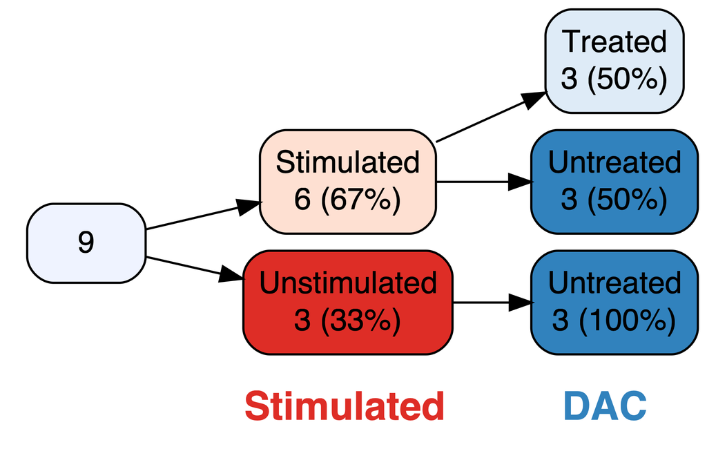

# Analysis

## 1. Calling base-level methylation percentage

```bash
mkdir data/03_augmented/01_rrbs_methylKit
mkdir data/03_augmented/01_rrbs_methylKit/01_meth_percentage
```

```r
bams <- as.list(list.files(path = file.path(r.config$dirs$clean.data.dir,"02_rrbs_bams"), pattern = "bam"))
bam.locations <- as.list(file.path(r.config$dirs$clean.data.dir,"02_rrbs_bams",bams))
bam.locations
sample.name <- lapply(X = bams, FUN = function(X){
  this.bam <- X
  strsplit(x = this.bam, split = "_")[[1]][1]
})
treatment <- rep(c(0,1,2),3)
names(treatment) <- sample.name
meth.raw <- processBismarkAln(location = bam.locations, sample.id = sample.name, assembly="hg19", read.context = "CpG", save.folder = file.path(r.config$dirs$augmented.data.dir,"01_rrbs_methylKit","01_meth_percentage"), save.context = "CpG", treatment = treatment)
```

Once `methylKit` has processed the bam files, it outputs text files summarising the methylation data for each sample. I’ve saved these in the directory `data/03_augmented/01_rrbs_methylKit`. These can be quickly read in using the `methRead()` function.

```r
meth.files <- as.list(list.files(path = file.path(r.config$dirs$augmented.data.dir,"01_rrbs_methylKit","01_meth_percentage"), pattern = "CpG.txt"))
meth.files <- as.list(file.path(r.config$dirs$augmented.data.dir,"01_rrbs_methylKit","01_meth_percentage",meth.files))
meth.ids <- lapply(X = meth.files, FUN = function(X){
  this.meth <- X
  strsplit(x = this.meth, split = "/")[[1]][length(strsplit(x = this.meth, split = "/")[[1]])]
})
sample.name <- lapply(X = meth.ids, FUN = function(X){
  this.meth <- X
  strsplit(x = this.meth, split = "_")[[1]][1]
})
treatment <- rep(c(0,1,2),3)
names(treatment) <- sample.name
meth.raw <- methRead(location = meth.files, sample.id = sample.name, assembly="hg19", context = "CpG", treatment = treatment)
```

## 2. Visualising the bisulphite conversion rates of each sample

`MethylKit` outputs the bisulphite conversion rate of each sample alongside the methylation data as files named `_conversionStats.txt`.

```r
stats.files <- list.files(path = file.path(r.config$dirs$augmented.data.dir,"01_rrbs_methylKit","01_meth_percentage"), pattern = "_conversionStats.txt")
conversion.stats <- lapply(X = stats.files, FUN = function(X){
  this.file <- X
  this.table <- read.table(text = gsub(pattern = ":|=", replacement = "\t", x = readLines(con = file.path(r.config$dirs$augmented.data.dir,"01_rrbs_methylKit","01_meth_percentage",this.file))), sep = "\t", header = FALSE, skip = 2, stringsAsFactors = FALSE, col.names = c("Statistic","Count"), row.names = 1)
})
names(conversion.stats) <- stats.files
```

```r
conversion.stats.ma <- matrix(data = unlist(conversion.stats), nrow = 6, ncol = 9, byrow = FALSE)
conversion.stats.ma <- conversion.stats.ma[c(2,4,6),]
colnames(conversion.stats.ma) <- unique(metadata$`Sequencing ID`)
rownames(conversion.stats.ma) <- c("Average","Forward","Reverse")
conversion.stats.ma
```

```
##             5700     5701     5702     5703     5704     5705       H1      H2
## Average 99.84867 99.86651 99.89017 99.83630 99.85322 99.92184 99.86509 99.8862
## Forward 99.84825 99.86621 99.89116 99.83608 99.85285 99.92161 99.86421 99.8857
## Reverse 99.84908 99.86681 99.88919 99.83653 99.85359 99.92208 99.86596 99.8867
##               H3
## Average 99.91820
## Forward 99.91766
## Reverse 99.91875
```

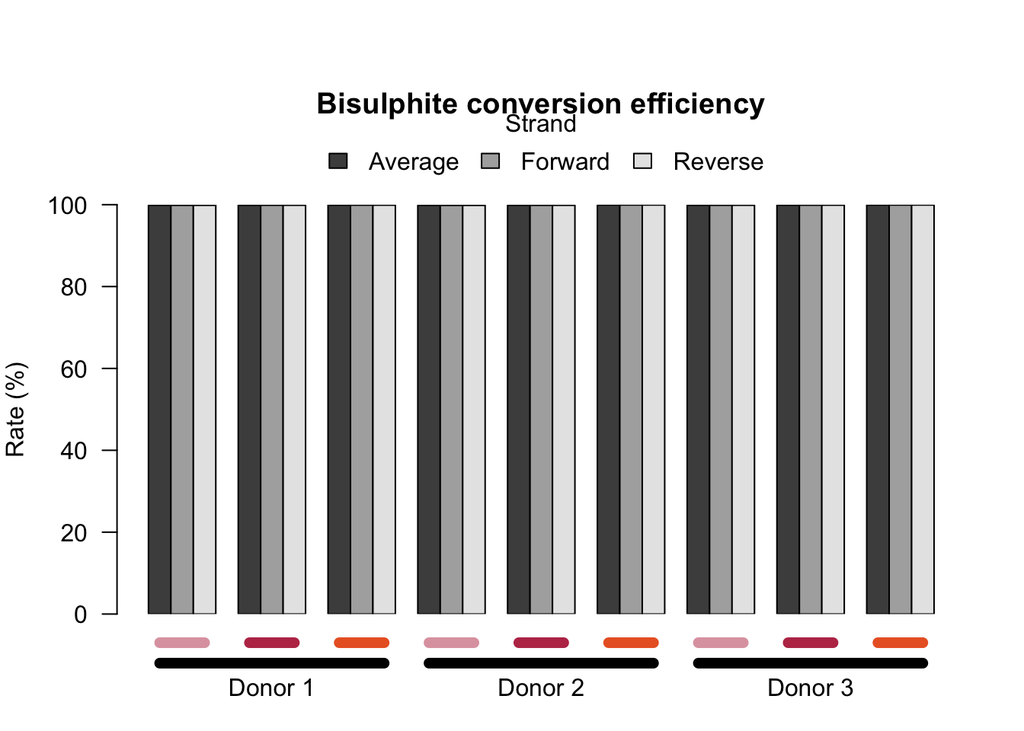

```r
bp <- barplot(height = conversion.stats.ma, beside = TRUE, plot = FALSE)
x.text <- bp[2,c(2,5,8)]
x.lines <- bp[c(1,3),]
par(mar = c(4,4,7,2))
barplot(height = conversion.stats.ma, beside = TRUE, ylim = c(0,100), xpd = FALSE, names.arg = rep("",9), ylab = "Rate (%)", main = "Bisulphite conversion efficiency", las = 1)
mtext(text = unique(metadata$`Donor ID (simple)`), side = 1, line = 2, at = x.text)
lines(x = c(bp[1,1],bp[3,3]), y = c(-12,-12), xpd = TRUE, lwd = 7)
lines(x = c(bp[1,4],bp[3,6]), y = c(-12,-12), xpd = TRUE, lwd = 7)
lines(x = c(bp[1,7],bp[3,9]), y = c(-12,-12), xpd = TRUE, lwd = 7)
for(i in 1:ncol(x.lines)){
  lines(x = x.lines[,i], y = c(-7,-7), xpd = TRUE, lwd = 7, col = rep(r.config$simple.cols,3)[i])
}
legend("top", legend = rownames(conversion.stats.ma), fill = grey.colors(n = 3), horiz = TRUE, bty = "n", inset = -0.25, xpd = TRUE, title = "Strand")
```

```r
png.name <- file.path(r.config$dirs$figure.dir,"RRBS_S01_bisulphiteConversion.png")
png(filename = png.name, width = r.config$fig.specs$width, height = r.config$fig.specs$height, units = r.config$fig.specs$units, res = r.config$fig.specs$res, pointsize = r.config$fig.specs$pointsize)
par(mar = c(4,4,7,2))
barplot(height = conversion.stats.ma, beside = TRUE, ylim = c(0,100), xpd = FALSE, names.arg = rep("",9), ylab = "Rate (%)", main = "Bisulphite conversion efficiency", las = 1)
mtext(text = unique(metadata$`Donor ID (simple)`), side = 1, line = 2, at = x.text)
lines(x = c(bp[1,1],bp[3,3]), y = c(-12,-12), xpd = TRUE, lwd = 7)
lines(x = c(bp[1,4],bp[3,6]), y = c(-12,-12), xpd = TRUE, lwd = 7)
lines(x = c(bp[1,7],bp[3,9]), y = c(-12,-12), xpd = TRUE, lwd = 7)
for(i in 1:ncol(x.lines)){
  lines(x = x.lines[,i], y = c(-7,-7), xpd = TRUE, lwd = 7, col = rep(r.config$simple.cols,3)[i])
}
legend("top", legend = rownames(conversion.stats.ma), fill = grey.colors(n = 3), horiz = TRUE, bty = "n", inset = -0.25, xpd = TRUE, title = "Strand")
dev.off()
```

The bisulphite conversion rates look beautiful!

## 3. Filtering and uniting the CpGs

I’ll filter the data to remove bases with <10 reads and the highest coverage (possible PCR duplications).

```r
meth.filtered <- filterByCoverage(methylObj = meth.raw, lo.count = 10, lo.perc = NULL, hi.count = NULL, hi.perc = 99.9)
meth.base <- unite(object = meth.filtered, destrand = TRUE)
```

```
## destranding...
```

```
## uniting...
```

## 4. Outputting a table of the C/T counts and coverage for each sample

```r
meth.df <- getData(x = meth.base)
```

```r
rrbs_ct_counts <- meth.df
colnames(rrbs_ct_counts)[5:ncol(rrbs_ct_counts)] <- paste(c("coverage","numCs","numTs"),rep(unlist(sample.name), each = 3), sep = ".")
write.table(x = rrbs_ct_counts, file = file.path(r.config$dirs$table.dir,"rrbs_ct_counts.txt"), sep = "\t", quote = FALSE, row.names = FALSE)
```

```bash
pigz results/tables/rrbs_ct_counts.txt
```

## 5. Visualising methylation percentage per sample;

I’ll look at the methylation percentage values for the raw and filtered data.

Here are the methylation and coverage statistics for the raw data:

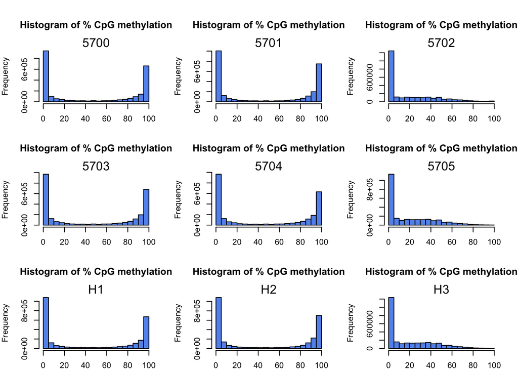

```r
par(mar = c(2,4,5,2), xpd = TRUE, mfrow = c(3,3))
lapply(X = meth.raw, FUN = function(X) getMethylationStats(object = X, plot = TRUE, both.strands = FALSE, labels = FALSE))
```

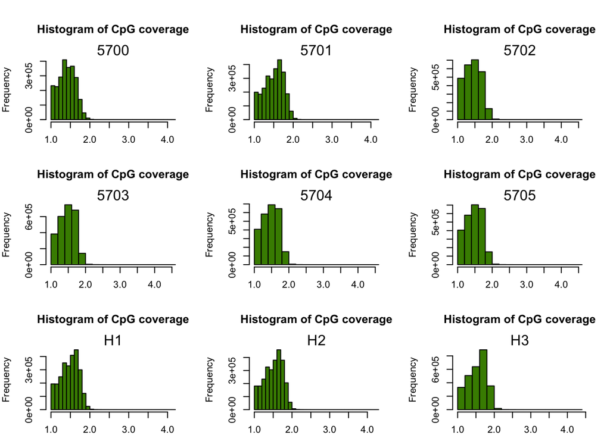

```r
lapply(X = meth.raw, FUN = function(X) getCoverageStats(object = X, plot = TRUE, both.strands = FALSE, labels = FALSE))
```

And here are the plots for the filtered data:

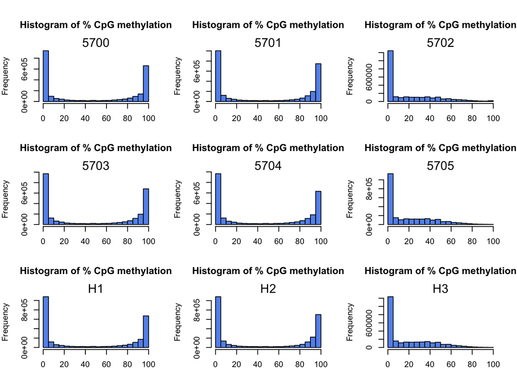

```r
par(mar = c(2,4,5,2), xpd = TRUE, mfrow = c(3,3))
lapply(X = meth.filtered, FUN = function(X) getMethylationStats(object = X, plot = TRUE, both.strands = FALSE, labels = FALSE))
```

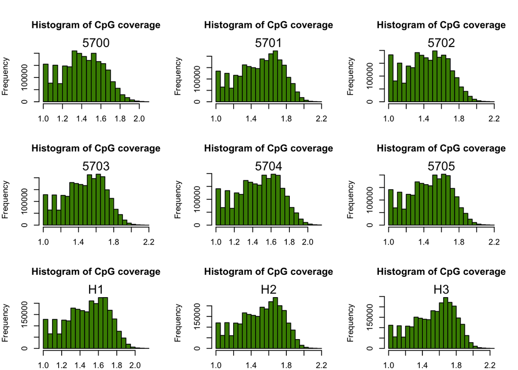

```r
lapply(X = meth.filtered, FUN = function(X) getCoverageStats(object = X, plot = TRUE, both.strands = FALSE, labels = FALSE))
```

I’ll create publication quality figures summarising this data.

```r
meth.prop <- array(data = NA, dim = c(nrow(meth.df),length(sample.name)))
for(i in 1:length(sample.name)){
  this.sample <- i
  col.index <- grep(pattern = this.sample, x = colnames(meth.df))
  these.columns <- meth.df[,col.index]
  this.prop <- these.columns[,2]/these.columns[,1]
  meth.prop[,this.sample] <- this.prop
}
classes <- apply(X = metadata[,c("Stimulated","DAC")], MARGIN = 1, FUN = function(X){
  this.row <- X
  paste(this.row, collapse = "_")
})
classes.unique <- unique(classes)
meth.prop.mean <- array(data = NA, dim = c(nrow(meth.df), length(unique(classes))))
for(i in 1:length(classes.unique)){
 this.class <- classes.unique[i]
 col.index <- grep(pattern = this.class, x = classes)
 these.columns <- meth.prop[,col.index]
 row.means <- rowMeans(these.columns)
 meth.prop.mean[,i] <- row.means
}
```

I’ll plot the mean methylation as a density line graph with a separate plot for each sample.

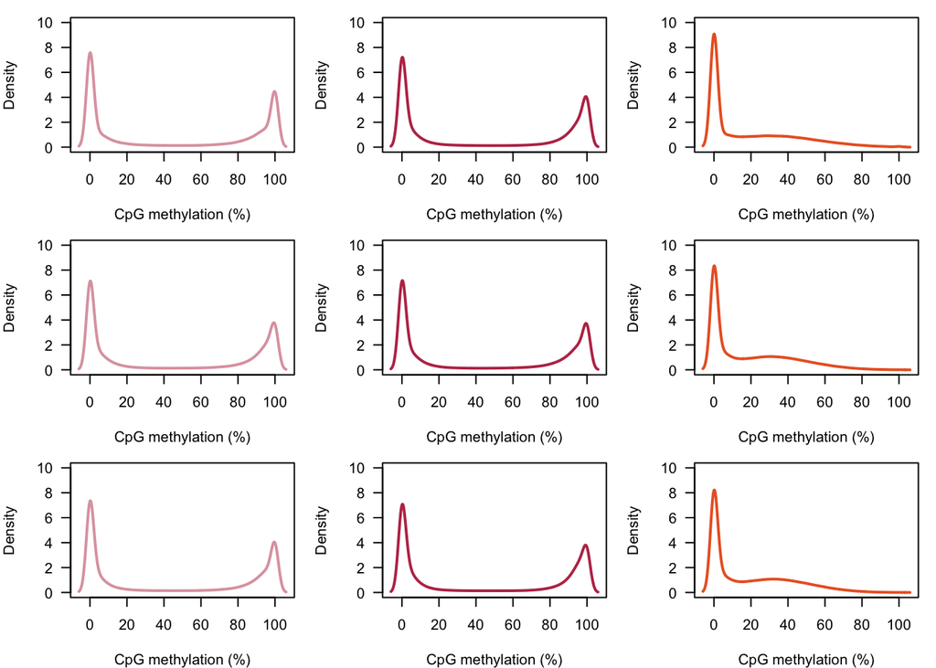

```r
densities <- lapply(X = seq_along(1:ncol(meth.prop)), FUN = function(i){
  this.col <- meth.prop[,i]
  density(x = this.col, bw = 0.02)
})
xlab <- "CpG methylation (%)"
ylab <- "Density"
ylim <- c(0, max(densities[[3]]$y) * 1.1)
par(mfrow = c(3,3), mar = c(4,4,1,1))
for(i in 1:length(classes)){
    plot(x = densities[[i]]$x * 100, y = densities[[i]]$y, ylim = ylim, xlab = xlab, ylab = ylab, type = "l", lwd = 2, col = rep(r.config$simple.cols,3)[i], las = 1)
}
```

```r
for(i in 1:nrow(metadata)){
  this.sample <- metadata$`Sequencing ID`[i]
  png.name <- file.path(r.config$dirs$figure.dir,paste0("RRBS_S02_methDensity_",this.sample,".png"))
  png(filename = png.name, width = 2, height = 2, units = r.config$fig.specs$units, res = r.config$fig.specs$res, pointsize = r.config$fig.specs$pointsize)
  par(mar = c(1,1,1,1))
  plot(x = densities[[i]]$x * 100, y = densities[[i]]$y, ylim = ylim, xlab = xlab, ylab = ylab, type = "l", lwd = 2, col = rep(r.config$simple.cols,3)[i], las = 1, axes = FALSE)
  axis(side = 1, at = seq(0,100,20), labels = rep("",6))
  axis(side = 2, at = seq(0,10,2), labels = rep("",6))
  dev.off()
}
```

## 6. Visualising the average the base-level methylation for each sample group

I’ll average the base-level CpG methylation for each sample group and plot density.

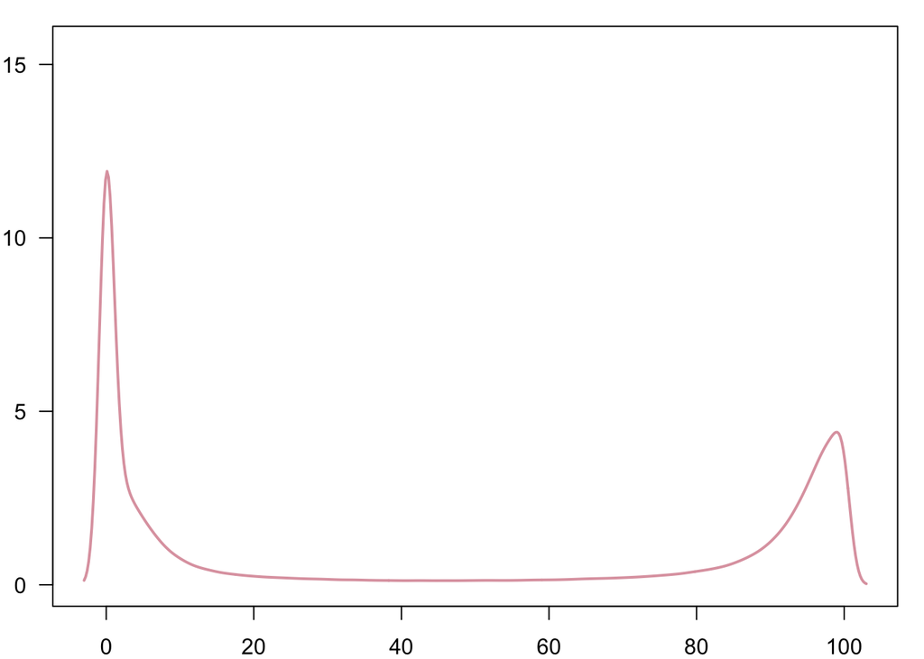

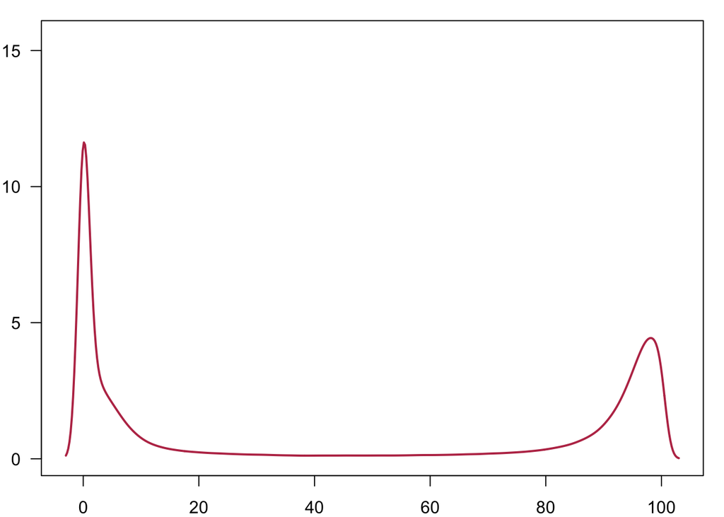

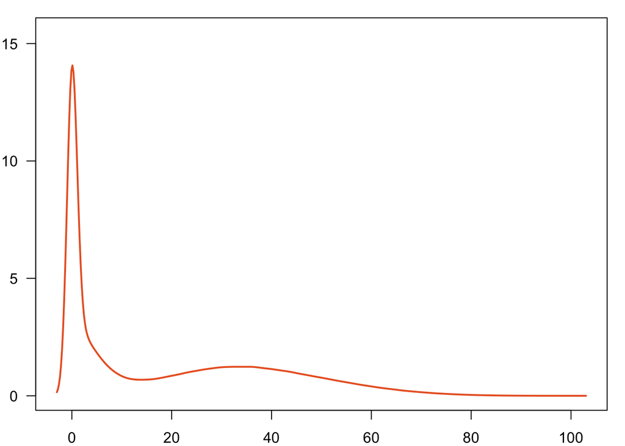

```r
densities <- lapply(X = seq_along(1:length(r.config$simple.cols)), FUN = function(i){
  this.col <- meth.prop.mean[,i]
  density(x = this.col, bw = 0.01)
})
xlab <- "CpG methylation (%)"
ylab <- "Density"
ylim <- c(0, max(densities[[3]]$y) * 1.1)
par(mar = c(2,2,1,1))
for(i in 1:length(classes.unique)){
  plot(x = densities[[i]]$x * 100, y = densities[[i]]$y, ylim = ylim, xlab = xlab, ylab = ylab, type = "l", lwd = 2, col = r.config$simple.cols[i], las = 1)
}
```

```r
for(i in 1:length(classes.unique)){
  png.name <- file.path(r.config$dirs$figure.dir,paste0("RRBS_01_methDensity_byGroup_",classes.unique[i],".png"))
  png(filename = png.name, width = 2.5, height = 2.5, units = r.config$fig.specs$units, res = r.config$fig.specs$res, pointsize = r.config$fig.specs$pointsize)
  par(mar = c(1,1,1,1))
  plot(x = densities[[i]]$x * 100, y = densities[[i]]$y, ylim = ylim, xlab = xlab, ylab = ylab, type = "l", lwd = 2, col = r.config$simple.cols[i], las = 1, axes = FALSE)
  axis(side = 1, at = seq(0,100,20), labels = rep("",6))
  axis(side = 2, at = c(0,5,10,15), las = 1, labels = rep("",4))
  dev.off()
}
```

## 7. Visualising the pairwise Spearman correlation co-efficients for each sample

Finally, I’ll look at the correlation in methylation between samples. We would expect to see less correlation between the DAC treated samples and all others.

```r
meth.table <- getData(x = meth.base)
meth.array <- array(data = NA, dim = c(nrow(meth.table),9))
colnames(meth.array) <- sample.name
for(i in 1:9){
  this.cov <- meth.table[,grep(pattern = i, x = colnames(x = meth.table))]
  meth.prop <- this.cov[,2]/this.cov[,1]
  meth.array[,i] <- meth.prop
}
meth.cor <- cor(x = meth.array, method = "spearman")
```

Now, let’s plot the matrix of correlation co-efficients as a heatmap.

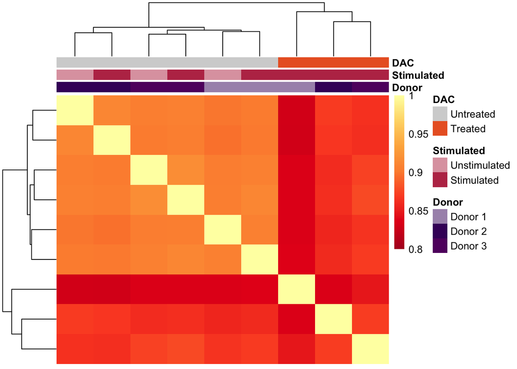

```r
dendro <- hclust(as.dist(1-meth.cor), method = "ward.D2")
breaksList <- seq(0.8, 1, by = 0.001)
cols <- colorRampPalette(rev(brewer.pal(n = 7, name = "YlOrRd")))(length(breaksList))
annotation_col <- data.frame(metadata[,3:5], row.names = metadata$`Sequencing ID`)
colnames(annotation_col)[1] <- "Donor"

pheatmap(mat = meth.cor, color = cols, breaks = breaksList, border_color = NA, cluster_rows = dendro,cluster_cols = dendro, annotation_col = annotation_col, annotation_colors = r.config$fig.cols, show_rownames = FALSE, show_colnames = FALSE)
```

```r
png.name <- file.path(r.config$dirs$figure.dir,"RRBS_02_corHeatmap.png")
png(filename = png.name, width = 8, height = r.config$fig.specs$height, units = r.config$fig.specs$units, res = r.config$fig.specs$res, pointsize = r.config$fig.specs$pointsize)
pheatmap(mat = meth.cor, color = cols, breaks = breaksList, border_color = NA, cluster_rows = dendro,cluster_cols = dendro, annotation_col = annotation_col, annotation_colors = r.config$fig.cols, show_rownames = FALSE, show_colnames = FALSE, treeheight_row = 15, treeheight_col = 15, fontsize = 6, cellwidth = 12, cellheight = 12)
dev.off()
```